title: “Estatìstica e Probabilidade”

subtitle: “Distribuições de Probabilidade e Aplicações Escolares”

author: “Reinaldo Gomes”

date: “09/10/26”

# 1. Introdução

Este relatório aplica as distribuições Normal, Binomial, Poisson, Exponencial, Weibull e Gama a situações relacionadas à comunidade escolar. São calculadas probabilidades, esperanças, variâncias e quantis, acompanhados de gráficos e simulações em R.

**Nota metodológica:** como alguns parâmetros não apareceram preenchidos no enunciado, adotam-se valores didáticos: Normal com média 520 e desvio padrão 80; Poisson com média 3 eventos por semana; Weibull com forma 2 e escala 160 cm; Gama com forma 4 e taxa 0,02. Os dados são hipotéticos e devem ser substituídos pelos parâmetros originais, caso estejam disponíveis.

# 2. Fundamentação teórica

Variáveis discretas representam contagens; variáveis contínuas representam medidas. As funções do R iniciadas por `d` calculam probabilidades pontuais ou densidades, `p` calcula probabilidades acumuladas, `q` calcula quantis e `r` gera valores aleatórios.

| Distribuição | Esperança | Variância |
| --- | --- | --- |
| Normal | $\mu$ | $\sigma^2$ |
| Binomial | $np$ | $np(1-p)$ |
| Poisson | $\lambda$ | $\lambda$ |
| Exponencial | $1/\lambda$ | $1/\lambda^2$ |
| Weibull | $\eta\Gamma(1+1/k)$ | $\eta^2[\Gamma(1+2/k)-\Gamma(1+1/k)^2]$ |
| Gama | $\alpha/\beta$ | $\alpha/\beta^2$ |

# 3. Parte 1 — Desempenho em Matemática: Normal

Adota-se $X\sim N(520,80^2)$.

## a) Probabilidade de nota inferior a 400

```r
mu <- 520
sigma <- 80
p1a <- pnorm(400, mean=mu, sd=sigma)
cat("P(X < 400) =", round(p1a,4), "ou",
    round(100*p1a,2), "%")
```

```
## P(X < 400) = 0.0668 ou 6.68 %
```

Resposta: aproximadamente 6,68%.

## b) Probabilidade de nota entre 500 e 650

```r
p1b <- pnorm(650,mu,sigma)-pnorm(500,mu,sigma)
cat("P(500 < X < 650) =", round(p1b,4), "ou",
    round(100*p1b,2), "%")
```

```
## P(500 < X < 650) = 0.5466 ou 54.66 %
```

Resposta: aproximadamente 54,66%.

## c) Percentil 10

```r
p1c <- qnorm(0.10,mu,sigma)
cat("Percentil 10 =", round(p1c,2), "pontos")
```

```
## Percentil 10 = 417.48 pontos
```

Resposta: aproximadamente 417,48 pontos.

## d) Probabilidade de a média de 25 alunos superar 550

```r
p1d <- pnorm(550, mean=mu, sd=sigma/sqrt(25),
             lower.tail=FALSE)
cat("P(media amostral > 550) =", round(p1d,4), "ou",
    round(100*p1d,2), "%")
```

```
## P(media amostral > 550) = 0.0304 ou 3.04 %
```

Resposta: aproximadamente 3,04%.

## e) Simulação de 1.000 notas

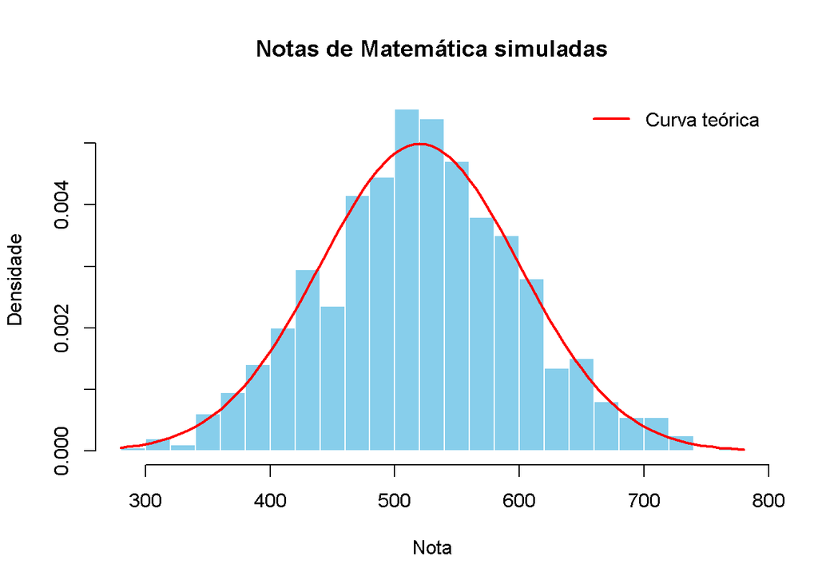

```r
set.seed(123)
notas <- rnorm(1000,mean=mu,sd=sigma)

hist(notas,probability=TRUE,breaks=25,
     col="skyblue",border="white",
     main="Notas de Matemática simuladas",
     xlab="Nota",ylab="Densidade")
curve(dnorm(x,mean=mu,sd=sigma),add=TRUE,
      col="red",lwd=2)
legend("topright","Curva teórica",col="red",
       lwd=2,bty="n")
```

```r
cat("Média simulada:",round(mean(notas),2),"\n")
```

```
## Média simulada: 521.29
```

```r
cat("Desvio padrão simulado:",round(sd(notas),2))
```

```
## Desvio padrão simulado: 79.34
```

Interpretação: o histograma tende a acompanhar a curva Normal, embora ocorram diferenças devido à aleatoriedade.

# 4. Parte 2 — Aprovação na OBMEP: Binomial

Considere $X\sim B(20;0,25)$.

## a) Nenhum aluno classificado

```r
n <- 20
prob <- 0.25
p2a <- dbinom(0,n,prob)
cat("P(X=0) =",round(p2a,4),"ou",
    round(100*p2a,2),"%")
```

```
## P(X=0) = 0.0032 ou 0.32 %
```

Resposta: aproximadamente 0,32%.

## b) No máximo três classificados

```r
p2b <- pbinom(3,n,prob)
cat("P(X<=3) =",round(p2b,4),"ou",
    round(100*p2b,2),"%")
```

```
## P(X<=3) = 0.2252 ou 22.52 %
```

Resposta: aproximadamente 22,51%.

## c) Oito ou mais classificados

```r
p2c <- pbinom(7,n,prob,lower.tail=FALSE)
cat("P(X>=8) =",round(p2c,4),"ou",
    round(100*p2c,2),"%")
```

```
## P(X>=8) = 0.1018 ou 10.18 %
```

## d) Esperança e variância

```r
E_bin <- n*prob
Var_bin <- n*prob*(1-prob)
cat("Esperança =",E_bin,"alunos\n")
```

```
## Esperança = 5 alunos
```

```r
cat("Variância =",Var_bin,"alunos²")
```

```
## Variância = 3.75 alunos²
```

Resposta: esperança de 5 alunos e variância de 3,75 alunos².

## e) Simulação de 1.000 turmas

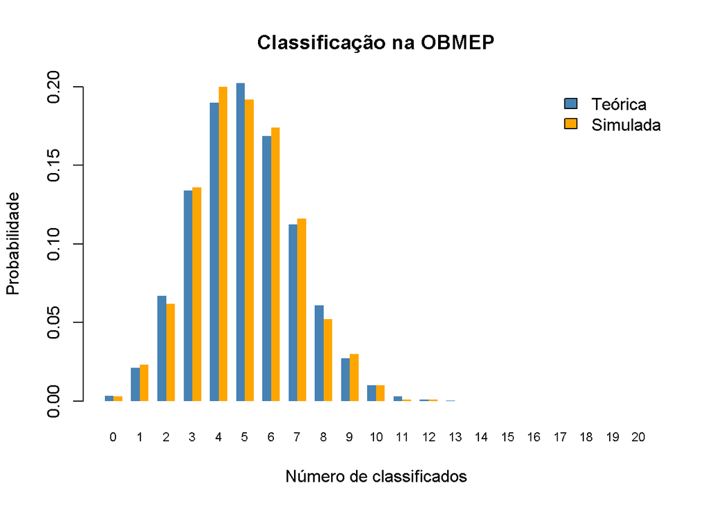

```r
set.seed(123)
sim_bin <- rbinom(1000,n,prob)
valores <- 0:n
freq <- tabulate(sim_bin+1,nbins=n+1)/1000
teorica <- dbinom(valores,n,prob)

barplot(rbind(teorica,freq),beside=TRUE,
        names.arg=valores,
        col=c("steelblue","orange"),border=NA,
        main="Classificação na OBMEP",
        xlab="Número de classificados",
        ylab="Probabilidade",cex.names=0.75)
legend("topright",c("Teórica","Simulada"),
       fill=c("steelblue","orange"),bty="n")
```

Interpretação: as frequências relativas simuladas tendem a se aproximar das probabilidades teóricas com o aumento das simulações.

# 5. Parte 3 — Evasão escolar: Poisson

Adota-se uma média hipotética de 3 abandonos por semana.

## a) Nenhuma evasão

```r
lambda <- 3
p3a <- dpois(0,lambda)
cat("P(X=0) =",round(p3a,4),"ou",
    round(100*p3a,2),"%")
```

```
## P(X=0) = 0.0498 ou 4.98 %
```

Resposta: aproximadamente 4,98%.

## b) Cinco ou mais evasões

```r
p3b <- ppois(4,lambda,lower.tail=FALSE)
cat("P(X>=5) =",round(p3b,4),"ou",
    round(100*p3b,2),"%")
```

```
## P(X>=5) = 0.1847 ou 18.47 %
```

Resposta: aproximadamente 18,47%.

## c) Entre duas e quatro evasões

```r
p3c <- ppois(4,lambda)-ppois(1,lambda)
cat("P(2<=X<=4) =",round(p3c,4),"ou",
    round(100*p3c,2),"%")
```

```
## P(2<=X<=4) = 0.6161 ou 61.61 %
```

Resposta: aproximadamente 61,60%.

## d) Exatamente sete evasões em duas semanas

```r
p3d <- dpois(7,lambda=6)
cat("P(X=7 em duas semanas) =",round(p3d,4),"ou",
    round(100*p3d,2),"%")
```

```
## P(X=7 em duas semanas) = 0.1377 ou 13.77 %
```

Resposta: aproximadamente 13,76%.

## e) Esperança e variância

```r
cat("Esperança =",lambda,"eventos por semana\n")
```

```
## Esperança = 3 eventos por semana
```

```r
cat("Variância =",lambda,"eventos²")
```

```
## Variância = 3 eventos²
```

Resposta: esperança e variância iguais a 3.

Interpretação: a Poisson descreve contagens por intervalo. A análise da evasão deve considerar dados reais e fatores sociais.

# 6. Parte 4 — Tempo de espera: Exponencial

A média é 12 minutos e a taxa é $1/12$.

## a) Espera superior a 20 minutos

```r
taxa <- 1/12
p4a <- pexp(20,rate=taxa,lower.tail=FALSE)
cat("P(X>20) =",round(p4a,4),"ou",
    round(100*p4a,2),"%")
```

```
## P(X>20) = 0.1889 ou 18.89 %
```

Resposta: aproximadamente 18,89%.

## b) Espera inferior a cinco minutos

```r
p4b <- pexp(5,rate=taxa)
cat("P(X<5) =",round(p4b,4),"ou",
    round(100*p4b,2),"%")
```

```
## P(X<5) = 0.3408 ou 34.08 %
```

Resposta: aproximadamente 34,08%.

## c) Mediana

```r
p4c <- qexp(0.5,rate=taxa)
cat("Mediana =",round(p4c,2),"minutos")
```

```
## Mediana = 8.32 minutos
```

Resposta: aproximadamente 8,32 minutos.

## d) Já esperou dez minutos: esperar pelo menos mais oito

```r
p4d <- pexp(18,rate=taxa,lower.tail=FALSE)/
       pexp(10,rate=taxa,lower.tail=FALSE)
cat("P(X>18 | X>10) =",round(p4d,4),"ou",
    round(100*p4d,2),"%\n")
```

```
## P(X>18 | X>10) = 0.5134 ou 51.34 %
```

```r
cat("P(X>8) =",round(pexp(8,rate=taxa,
                           lower.tail=FALSE),4))
```

```
## P(X>8) = 0.5134
```

Resposta: aproximadamente 51,34%. Pela propriedade da falta de memória, a probabilidade condicional coincide com $P(X>8)$.

## e) Simulação de 1.000 tempos

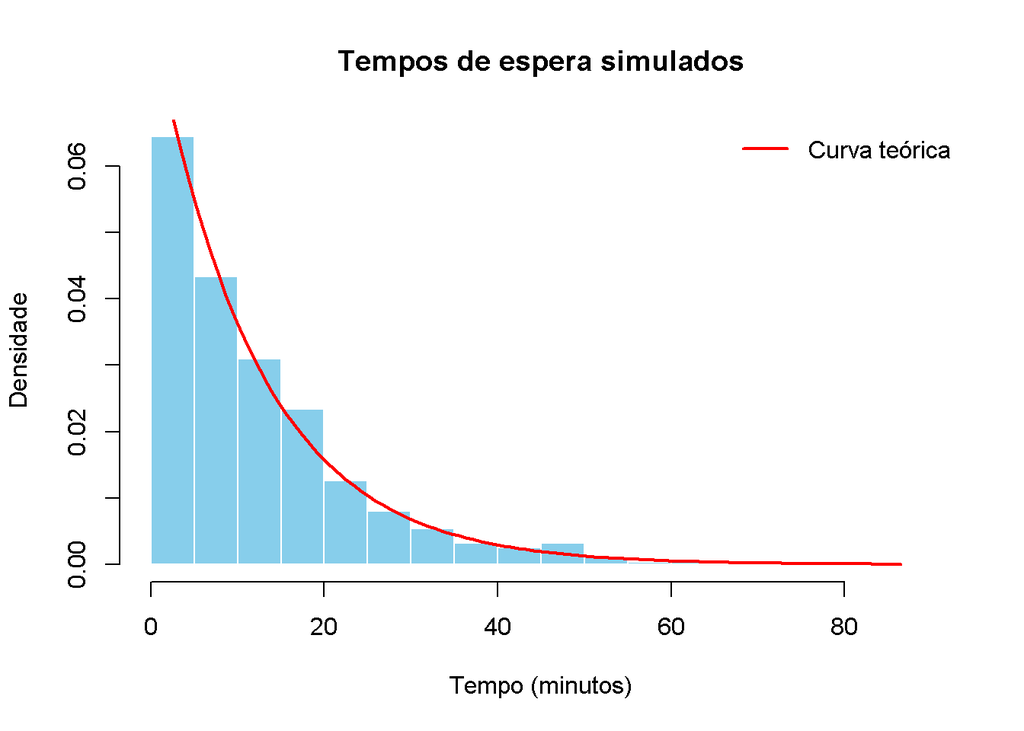

```r
set.seed(123)
tempos <- rexp(1000,rate=1/12)

hist(tempos,probability=TRUE,breaks=25,
     col="skyblue",border="white",
     main="Tempos de espera simulados",
     xlab="Tempo (minutos)",ylab="Densidade")
curve(dexp(x,rate=1/12),from=0,to=max(tempos),
      add=TRUE,col="red",lwd=2)
legend("topright","Curva teórica",col="red",
       lwd=2,bty="n")
```

```r
cat("Média simulada =",round(mean(tempos),2),"minutos")
```

```
## Média simulada = 12.36 minutos
```

Interpretação: a distribuição é assimétrica à direita. Filas reais podem não obedecer perfeitamente ao modelo exponencial.

# 7. Parte 5 — Altura: Weibull

Adotam-se forma $k=2$ e escala $\eta=160$ cm. Esses parâmetros são ilustrativos e não realistas para representar diretamente alunos do 9º ano.

## a) Altura inferior a 140 cm

```r
k <- 2
eta <- 160
p5a <- pweibull(140,shape=k,scale=eta)
cat("P(X<140) =",round(p5a,4),"ou",
    round(100*p5a,2),"%")
```

```
## P(X<140) = 0.535 ou 53.5 %
```

## b) Altura entre 150 e 175 cm

```r
p5b <- pweibull(175,k,eta)-pweibull(150,k,eta)
cat("P(150<X<175) =",round(p5b,4),"ou",
    round(100*p5b,2),"%")
```

```
## P(150<X<175) = 0.1129 ou 11.29 %
```

## c) Percentil 90

```r
p5c <- qweibull(0.90,shape=k,scale=eta)
cat("Percentil 90 =",round(p5c,2),"cm")
```

```
## Percentil 90 = 242.79 cm
```

## d) Média, variância e desvio padrão

```r
E_w <- eta*gamma(1+1/k)
Var_w <- eta^2*(gamma(1+2/k)-gamma(1+1/k)^2)
DP_w <- sqrt(Var_w)
cat("Média =",round(E_w,2),"cm\n")
```

```
## Média = 141.8 cm
```

```r
cat("Variância =",round(Var_w,2),"cm²\n")
```

```
## Variância = 5493.81 cm²
```

```r
cat("Desvio padrão =",round(DP_w,2),"cm")
```

```
## Desvio padrão = 74.12 cm
```

## e) Função de risco

$$h(x)=\frac{k}{\eta}\left(\frac{x}{\eta}\right)^{k-1}.$$

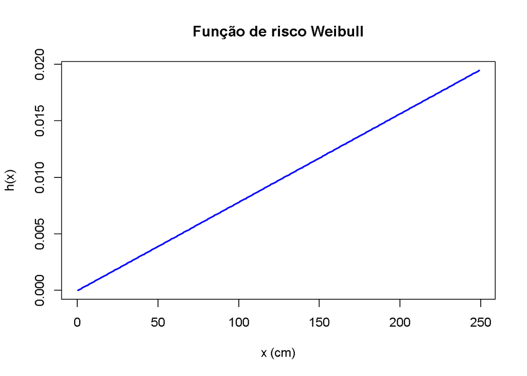

```r
x_seq <- seq(0.1,250,by=1)
hazard <- (k/eta)*(x_seq/eta)^(k-1)
plot(x_seq,hazard,type="l",lwd=2,col="blue",
     main="Função de risco Weibull",
     xlab="x (cm)",ylab="h(x)")
```

Interpretação: para $k=2$, a função é crescente. Neste exemplo, ela é uma aplicação matemática, não uma medida de risco biológico.

# 8. Parte 6 — Precipitação: Gama

Adotam-se forma $\alpha=4$ e taxa $\beta=0,02$.

## a) Chuva superior a 300 mm

```r
alpha <- 4
beta <- 0.02
p6a <- pgamma(300,shape=alpha,rate=beta,
              lower.tail=FALSE)
cat("P(X>300) =",round(p6a,4),"ou",
    round(100*p6a,2),"%")
```

```
## P(X>300) = 0.1512 ou 15.12 %
```

Resposta: aproximadamente 15,12%.

## b) Chuva entre 150 e 250 mm

```r
p6b <- pgamma(250,alpha,beta)-pgamma(150,alpha,beta)
cat("P(150<X<250) =",round(p6b,4),"ou",
    round(100*p6b,2),"%")
```

```
## P(150<X<250) = 0.3822 ou 38.22 %
```

Resposta: aproximadamente 38,22%.

## c) Percentil 95

```r
p6c <- qgamma(0.95,shape=alpha,rate=beta)
cat("Percentil 95 =",round(p6c,2),"mm")
```

```
## Percentil 95 = 387.68 mm
```

Resposta: aproximadamente 388 mm.

## d) Esperança, variância e desvio padrão

```r
E_g <- alpha/beta
Var_g <- alpha/beta^2
DP_g <- sqrt(Var_g)
cat("Esperança =",E_g,"mm\n")
```

```
## Esperança = 200 mm
```

```r
cat("Variância =",Var_g,"mm²\n")
```

```
## Variância = 10000 mm²
```

```r
cat("Desvio padrão =",DP_g,"mm")
```

```
## Desvio padrão = 100 mm
```

Resposta: média de 200 mm, variância de 10.000 mm² e desvio padrão de 100 mm.

## e) Simulação de 120 meses

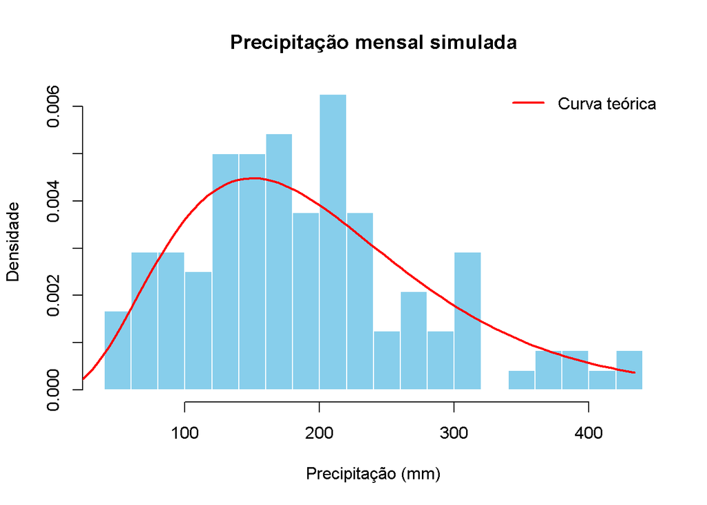

```r
set.seed(123)
chuva <- rgamma(120,shape=alpha,rate=beta)

hist(chuva,probability=TRUE,breaks=15,
     col="skyblue",border="white",
     main="Precipitação mensal simulada",
     xlab="Precipitação (mm)",ylab="Densidade")
curve(dgamma(x,shape=alpha,rate=beta),
      from=0,to=max(chuva),add=TRUE,
      col="red",lwd=2)
legend("topright","Curva teórica",col="red",
       lwd=2,bty="n")
```

```r
cat("Média simulada =",round(mean(chuva),2),"mm")
```

```
## Média simulada = 189.67 mm
```

Interpretação: a Gama pode representar variáveis positivas e assimétricas. A adequação à precipitação regional deve ser avaliada com dados meteorológicos reais.

# 9. Parte 7 — Monte Carlo com 10.000 simulações

```r
set.seed(123)
N <- 10000
notas_mc <- rnorm(N,mean=520,sd=80)

p_simulada <- mean(notas_mc<400)
p_teorica <- pnorm(400,mean=520,sd=80)

comparacao <- data.frame(
  Metodo=c("Monte Carlo","Teórico"),
  Probabilidade=c(p_simulada,p_teorica),
  Percentual=100*c(p_simulada,p_teorica)
)
knitr::kable(comparacao,digits=4,
             caption="Probabilidade de nota inferior a 400")
```

Probabilidade de nota inferior a 400

| Metodo | Probabilidade | Percentual |
| --- | --- | --- |
| Monte Carlo | 0.0670 | 6.7000 |
| Teórico | 0.0668 | 6.6807 |

```r
cat("Diferença absoluta =",
    round(abs(p_simulada-p_teorica),5),"\n")
```

```
## Diferença absoluta = 0.00019
```

```r
cat("Erro padrão aproximado =",
    round(sqrt(p_teorica*(1-p_teorica)/N),5))
```

```
## Erro padrão aproximado = 0.0025
```

Interpretação: a probabilidade teórica é aproximadamente 6,68%. A proporção simulada varia aleatoriamente em torno desse valor. Aumentar as simulações tende a reduzir a variabilidade da estimativa.

# 10. Resultados e discussão pedagógica

- **Normal:** notas aproximadamente simétricas; permite estudar média, dispersão e percentis.
- **Binomial:** número de classificados em tentativas independentes, com probabilidade constante.
- **Poisson:** contagem de eventos em um intervalo.
- **Exponencial:** tempos positivos de espera e propriedade da falta de memória.
- **Weibull:** variáveis positivas e função de risco dependente do parâmetro de forma.
- **Gama:** variáveis positivas e assimétricas, como certas medidas de precipitação.

Na Educação Básica, os gráficos e as simulações favorecem a investigação, a interpretação de dados, o pensamento computacional e a argumentação. Podem ser propostas atividades com notas anonimizadas, resultados de olimpíadas, tempos de atendimento e dados meteorológicos públicos.

A simulação não comprova, sozinha, que uma distribuição representa a realidade. É necessário confrontar o modelo com dados observados e avaliar suas hipóteses. A evasão escolar exige também análise de fatores sociais e institucionais.

# 11. Conclusão

Foram calculadas probabilidades, esperanças, variâncias e quantis de seis distribuições, além de gráficos e simulações. A comparação entre teoria e simulação permite compreender a variabilidade aleatória e os limites dos modelos.

No contexto do PROFMAT, a integração entre teoria, programação em R e situações contextualizadas pode fortalecer o ensino de Estatística e desenvolver o pensamento crítico dos estudantes, desde que os parâmetros e os dados sejam adequados.

# 12. Referências

BRASIL. Ministério da Educação. **Base Nacional Comum Curricular**. Brasília, DF: MEC, 2018.

BUSSAB, W. O.; MORETTIN, P. A. **Estatística Básica**. São Paulo: Saraiva.

MONTGOMERY, D. C.; RUNGER, G. C. **Estatística Aplicada e Probabilidade para Engenheiros**. Rio de Janeiro: LTC.

R CORE TEAM. **R: A Language and Environment for Statistical Computing**. Vienna: R Foundation for Statistical Computing. Disponível em: https://www.R-project.org/.

https://bendeivide.github.io/courses/profmat-probest/normal2026.2/

https://bendeivide.github.io/books/estbasica/